# Boyle_Logistic Regression

## 5.9 Visualiztion with Mosaic Plot

In this section, I create a mosaic plot to allow for visualization of the actual nd predicted values.

```r
#Putting the actual and predicted values into a table
mosaic_table <- table(final_data_meansplit_3$actual, final_data_meansplit_3$predicted)
mosaic_table #check on that table
```

```
##
##      0  1
##   0 87 37
##   1 33 91
```

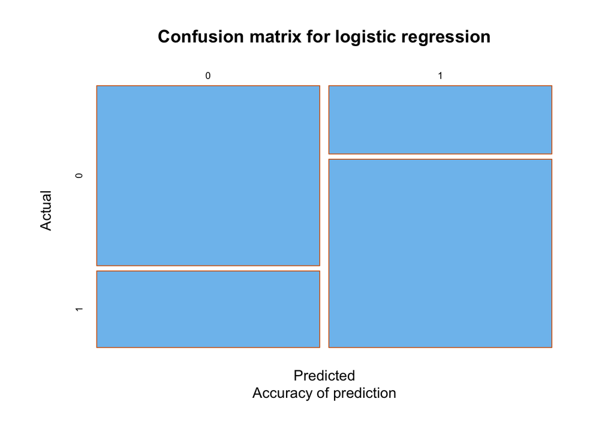

```r
#Running a simple mosaic plot to visualize the actual and predicted values
mosaicplot(mosaic_table,
           main = "Confusion matrix for logistic regression",
           sub = "Accuracy of prediction",
           xlab = "Predicted",
           ylab = "Actual",
           color = "skyblue2",
           border = "chocolate")
```

# 6 Discussion

The PCA showed that individual variables within the Classroom Atmosphere Rating Scale and the behavioral ratings could be reduced into 4 components. Those components were used within the logistic regression along with individuals predictor variables.

The model’s performance (as seen in the F1 score, kappa values, and the confusion matrix) indicates that these included variables are only moderately explaining student engagement. The model is not fully capturing all the important variables or factors that may predict student engagement.